# Untitled

VISHAL PATNAIK DAMODARAPATRUNI - s3811521

17/08/2021

# Introduction

The ASX data consists the monthly changes in all ordinaries (Ords) Price Index, Gold price (AUD), Crude Oil (Brent, USD/bbl) and Copper (USD/tonne) for 161 months, starting from 2004. This data is converted to Time series data.

Here, the time series data is analyzed for presence of stationary as well as the impact of components on the series data, then the respective models are fit on the series data to find the best model.

# Scope

This analysis has three parts: Part 1: Checking for Non - Stationary Part 2: Impact of components on the series data Part 3: Identifying the best fit model for ASX price index

## Part 1:

Identifying the trend and change in variance which makes the series stationary. Finally, performing Augumented Dicky Fuller test that says whether the series is stationary or not.

## Part 2:

Using suitable decomposition method analyse the impact of individual components on the series data.

## Part 3:

Finding the suitable distributed lag model among different models that best fits the ASX price index series.

# Method

Using the below packages (forecast, TSA, tseries, expsmooth, funitRoots etc.) the time series data is visualized and analysed based on the stationarity and the decomposed components. Then the best distributed lag model for the ASX price index is selected.

```r
library(expsmooth) # Forecasting with Exponential Smoothing. [1] - https://cran.r-project.org/web/packages/expsmooth/index.html
library(dplyr)
library(forecast) # Forecasting Functions for Time Series and Linear Models. [2] - https://cran.r-project.org/web/packages/forecast/index.html
library(tseries) # Time Series Analysis and Computational Finance.[3] - https://cran.r-project.org/web/packages/tseries/index.html
library(fUnitRoots) # To analyze trends and unit roots in financial time series. [4] - https://cran.r-project.org/web/packages/fUnitRoots/index.html
library(TSA) # Time Series Analysis.
library(urca) # Unit Root and Cointegration Tests. [5] - https://cran.r-project.org/web/packages/urca/index.html
library(readr)
library(dLagM) # Distributed lag model.
library(VIF)
```

# Data

The data is the monthly averages of all ordinaries (Ords) Price Index, Gold price (AUD), Crude Oil (Brent, USD/bbl) and Copper (USD/tonne). The data starts from 2004 and ends after 161 months. The dataset is in csv format and hence it is loaded using “read.csv()” function.

```r
v_ASX_data <- read.csv("ASX_data.csv", header = TRUE)
head(v_ASX_data)
```

|  | ASX.price | Gold.price | Crude.Oil..Brent._USD.bbl | Copper_USD.tonne |
| --- | --- | --- | --- | --- |
| 1 | 2935.4 | 611.9 | 31.29 | 1,650 |
| 2 | 2778.4 | 603.3 | 32.65 | 1,682 |
| 3 | 2848.6 | 565.7 | 30.34 | 1,656 |
| 4 | 2970.9 | 538.6 | 25.02 | 1,588 |
| 5 | 2979.8 | 549.4 | 25.81 | 1,651 |
| 6 | 2999.7 | 535.9 | 27.55 | 1,685 |

```r
# Using str() to check the type of each column.
str(v_ASX_data)
```

```
## 'data.frame':    161 obs. of  4 variables:
##  $ ASX.price                : num  2935 2778 2849 2971 2980 ...
##  $ Gold.price               : chr  "611.9" "603.3" "565.7" "538.6" ...
##  $ Crude.Oil..Brent._USD.bbl: num  31.3 32.6 30.3 25 25.8 ...
##  $ Copper_USD.tonne         : chr  "1,650" "1,682" "1,656" "1,588" ...
```

As the columns Gold.price and Copper_USD.tonne are in char format, which are supposed to be numeric. Now let us convert them into numeric format. For this let us remove “,” before converting.

```r
# Removing Commas
v_ASX_data$Gold.price = gsub(",","", v_ASX_data$Gold.price)
v_ASX_data$Copper_USD.tonne = gsub(",","", v_ASX_data$Copper_USD.tonne)

# Converting char to numeric
v_ASX_data$Gold.price = as.numeric(as.character(v_ASX_data$Gold.price))
v_ASX_data$Copper_USD.tonne = as.numeric(as.character(v_ASX_data$Copper_USD.tonne))
```

```r
str(v_ASX_data)
```

```
## 'data.frame':    161 obs. of  4 variables:
##  $ ASX.price                : num  2935 2778 2849 2971 2980 ...
##  $ Gold.price               : num  612 603 566 539 549 ...
##  $ Crude.Oil..Brent._USD.bbl: num  31.3 32.6 30.3 25 25.8 ...
##  $ Copper_USD.tonne         : num  1650 1682 1656 1588 1651 ...
```

Checking Missing values.

```r
colSums(is.na(v_ASX_data))
```

```
##                 ASX.price                Gold.price Crude.Oil..Brent._USD.bbl
##                         0                         0                         0
##          Copper_USD.tonne
##                         0
```

There are no missing values in the data.

Checking the class of v_ASX_data. (It should be data frame.)

```r
class(v_ASX_data)
```

```
## [1] "data.frame"
```

Converting each column into different time series objects. Here, I am taking start (2004, 1) because the data is monthly and is from 2004. Also, end (2017, 5) because there are 161 observations indicating 161 months which gives 13 years and 5 months. Frequency is 12 as there are 12 months in an year.

```r
v_ASX_price_TS <- ts(v_ASX_data$ASX.price, start = c(2004, 1), end = c(2017, 5), frequency = 12)
v_GOLD_price_TS <- ts(v_ASX_data$Gold.price, start = c(2004, 1), end = c(2017, 5), frequency = 12)
v_CRUDE_price_TS <- ts(v_ASX_data$Crude.Oil..Brent._USD.bbl, start = c(2004, 1), end = c(2017, 5), frequency = 12)
v_COPPER_price_TS <- ts(v_ASX_data$Copper_USD.tonne, start = c(2004, 1), end = c(2017, 5), frequency = 12)
```

Confirming the class of each time series object.

```r
class(v_ASX_price_TS)
```

```
## [1] "ts"
```

```r
class(v_GOLD_price_TS)
```

```
## [1] "ts"
```

```r
class(v_CRUDE_price_TS)
```

```
## [1] "ts"
```

```r
class(v_COPPER_price_TS)
```

```
## [1] "ts"
```

Now let us visualize each time series object.

# ASX price

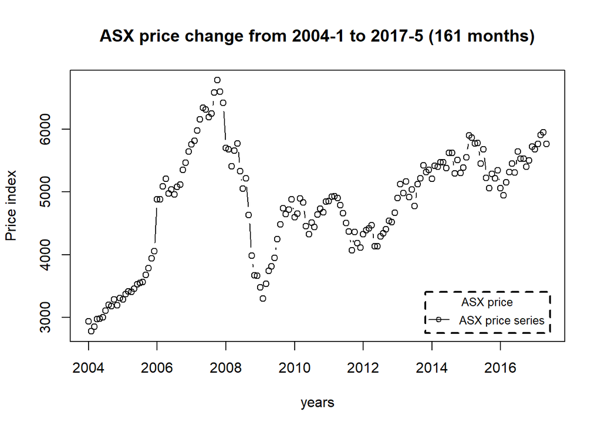

```r
plot(v_ASX_price_TS, type = "b", xlab = "years", ylab = "Price index", main = "ASX price change from 2004-1 to 2017-5 (161 months)", pch = 1)
legend("bottomright", inset = .03, title = "ASX price", legend = "ASX price series", horiz = TRUE, cex = 0.8, lty = 1, box.lty = 2, box.lwd = 2, pch = 1)
```

Fig 1: ASX price change - Time series plot.

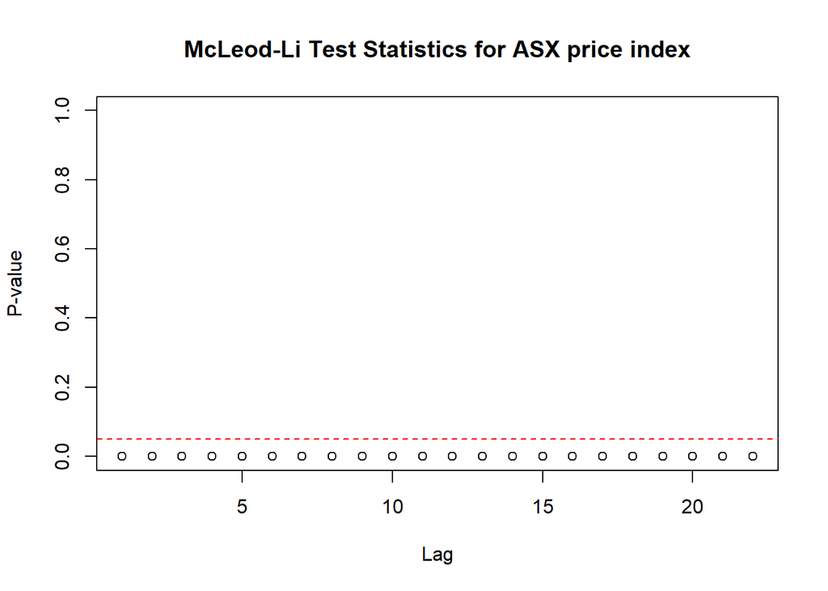

```r
McLeod.Li.test(y = v_ASX_price_TS, main = "McLeod-Li Test Statistics for ASX price index")
```

Fig 2: McLeod-Li Test Statistics for ASX price index.

Descriptive analysis

1. From fig1, we can observe an upward trend in the plot until 2017 with an intervention in the year 2008.
2. The ASX price series shows Autoregressive and moving average behaviour.
3. From fig1, we can conclude that there is no seasonality in the series.
4. From fig1 and fig2, we can see there a change in variance.

# GOLD price

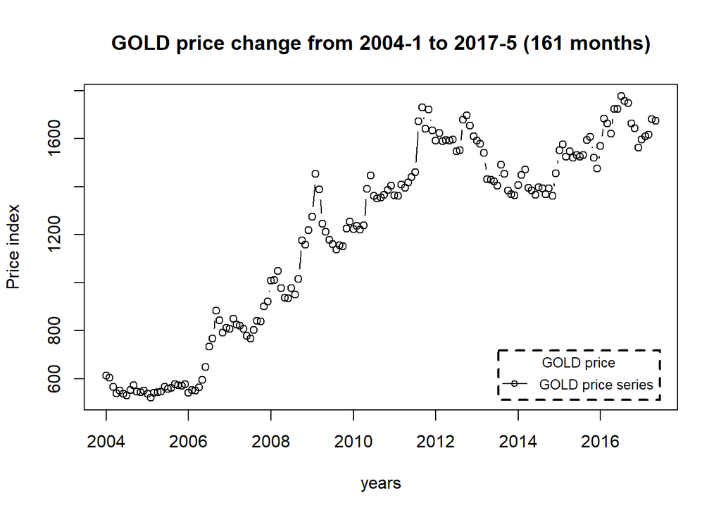

```r
plot(v_GOLD_price_TS, type = "b", xlab = "years", ylab = "Price index", main = "GOLD price change from 2004-1 to 2017-5 (161 months)", pch = 1)
legend("bottomright", inset = .03, title = "GOLD price", legend = "GOLD price series", horiz = TRUE, cex = 0.8, lty = 1, box.lty = 2, box.lwd = 2, pch = 1)
```

Fig 3: Gold price change - Time series plot.

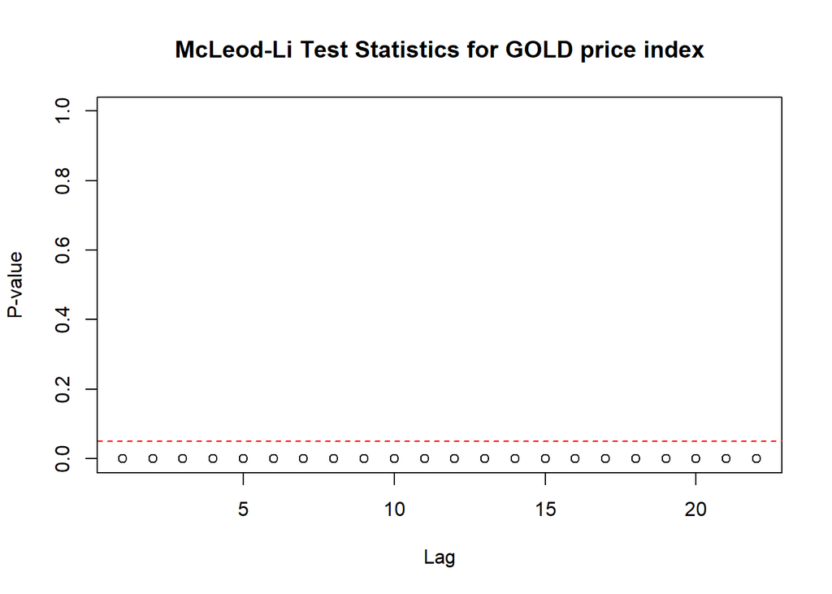

```r
McLeod.Li.test(y = v_GOLD_price_TS, main = "McLeod-Li Test Statistics for GOLD price index")
```

Fig 4: McLeod-Li Test Statistics for GOLD price index.

# CRUDE price

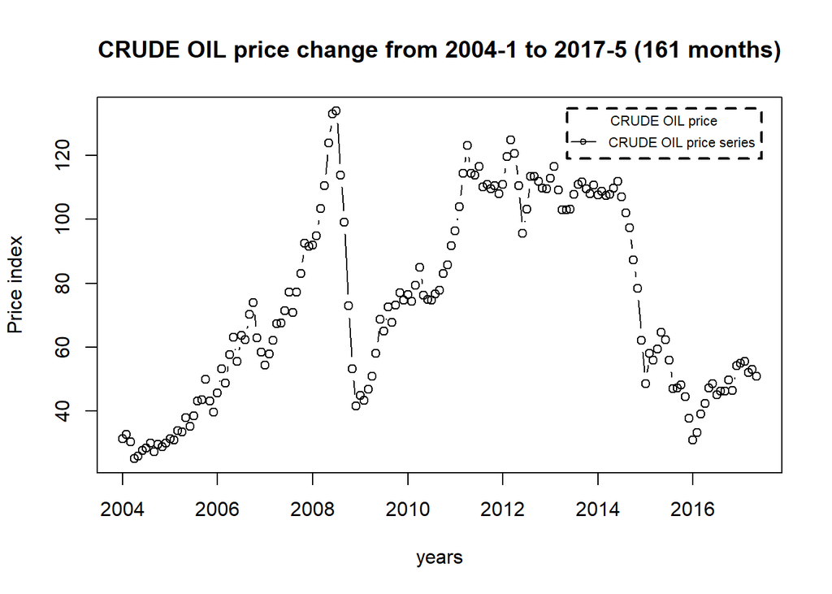

```r
plot(v_CRUDE_price_TS, type = "b", xlab = "years", ylab = "Price index", main = "CRUDE OIL price change from 2004-1 to 2017-5 (161 months)", pch = 1)
legend("topright", inset = .03, title = "CRUDE OIL price", legend = "CRUDE OIL price series", horiz = TRUE, cex = 0.7, lty = 1, box.lty = 2, box.lwd = 2, pch = 1)
```

Fig 5: Crude Oil price change - Time series plot.

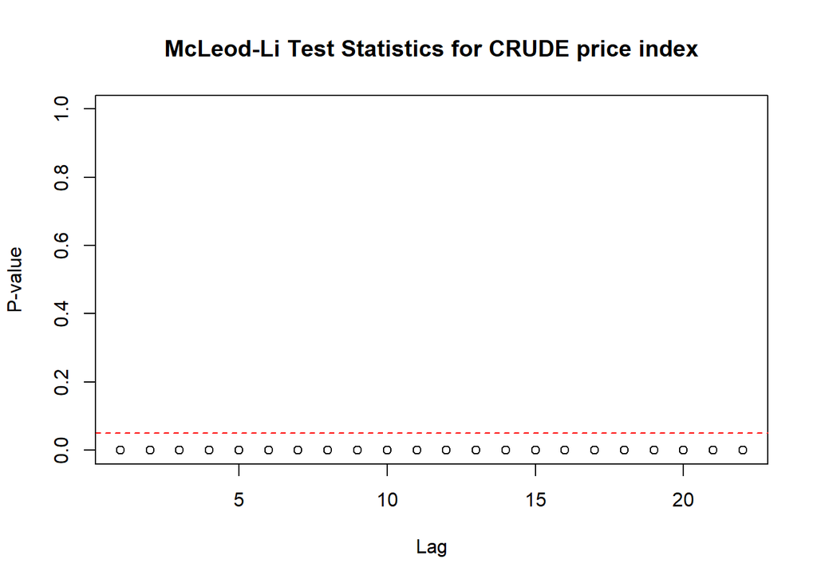

```r
McLeod.Li.test(y = v_CRUDE_price_TS, main = "McLeod-Li Test Statistics for CRUDE price index")
```

Fig 6: McLeod-Li Test Statistics for CRUDE price index.

Descriptive analysis

# COPPER price

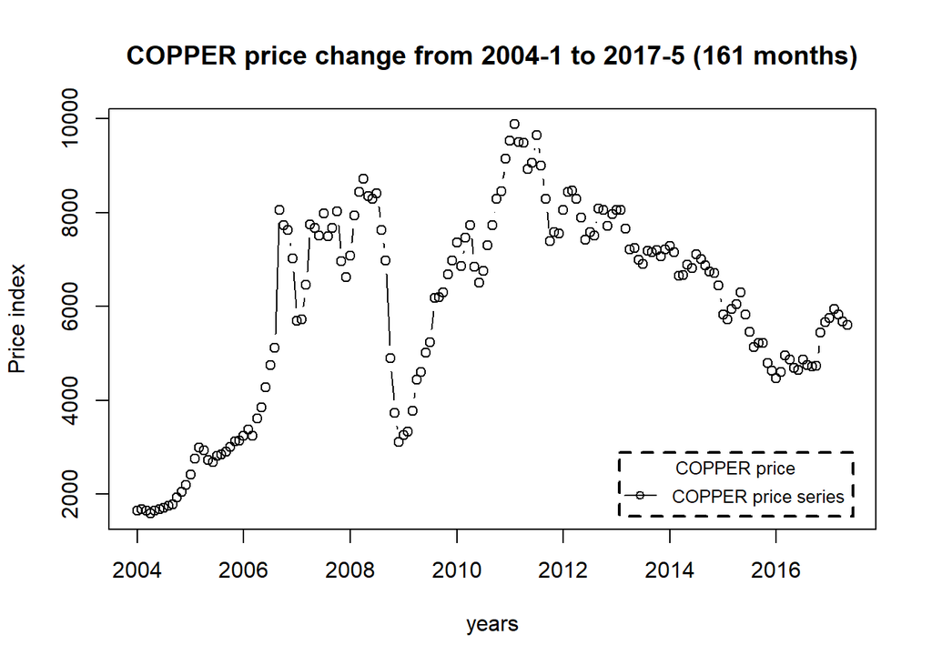

```r
plot(v_COPPER_price_TS, type = "b", xlab = "years", ylab = "Price index", main = "COPPER price change from 2004-1 to 2017-5 (161 months)", pch = 1)
legend("bottomright", inset = .03, title = "COPPER price", legend = "COPPER price series", horiz = TRUE, cex = 0.8, lty = 1, box.lty = 2, box.lwd = 2, pch = 1)
```

Fig 7: COPPER price change - Time series plot.

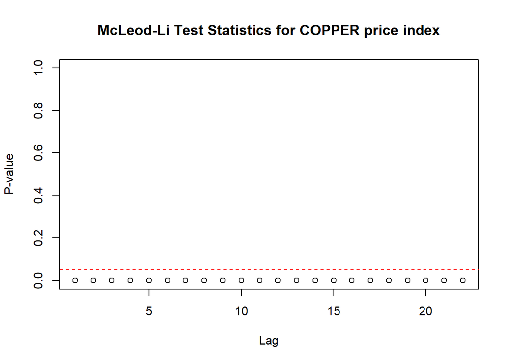

```r
McLeod.Li.test(y = v_COPPER_price_TS, main = "McLeod-Li Test Statistics for COPPER price index")
```

## The existence of Non - Stationary

```r
# Function to check Stationary on the series.
Stationary_Check <- function(x) {

  # Analysing trends by plotting ACF and PACF.
  par(mfrow = c(1,2))
  acf(x, main = "Price change - ACF")
  pacf(x, main = "Price change - PACF")

  # Conducting Augmented Dickey-Fuller test.
  adf.test(x)
}
```

Checking for Stationary on ASX price

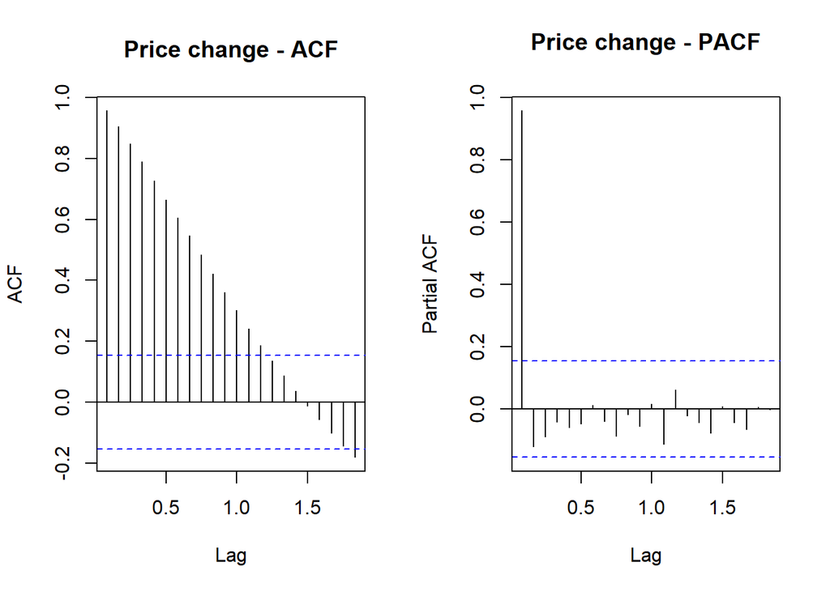

```
##
##  Augmented Dickey-Fuller Test
##
## data:  x
## Dickey-Fuller = -2.6995, Lag order = 5, p-value = 0.2846
## alternative hypothesis: stationary
```

```r
Stationary_Check(v_ASX_price_TS)
```

Fig 9: ASX price change - ACF Fig 10: ASX price change - PACF

The decrease in the ACF plot and a high peak in the PACF plot in the beginning, suggests that there is some pattern in the ASX price trend.

Hypotheses : H0 : The data is not stationary. HA : The data is stationary.

Also, as there is change in variance suggesting that the series is not stationary.

Therefore, the ASX price series is non - stationary.

Checking for Stationary on GOLD price

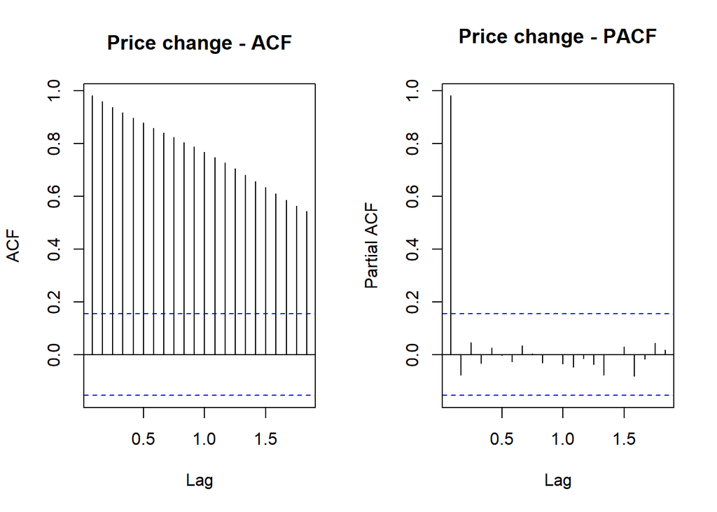

```
##
##  Augmented Dickey-Fuller Test
##
## data:  x
## Dickey-Fuller = -1.8369, Lag order = 5, p-value = 0.6444
## alternative hypothesis: stationary
```

```r
Stationary_Check(v_GOLD_price_TS)
```

Fig 11: GOLD price change - ACF Fig 12: GOLD price change - PACF

The decrease in the ACF plot and a high peak in the PACF plot in the beginning, suggests that there is some pattern in the GOLD price trend.

Hypotheses : H0 : The data is not stationary. HA : The data is stationary.

Interpretations: p - value : 0.6444 > 0.5

p - value is greater than 0.5 and hence the test is not statistically significant. Therefore, we fail to reject Null hypothesis i.e., The data is not stationary.

Also, as there is change in variance suggesting that the series is not stationary.

Therefore, the GOLD price series is non - stationary.

Checking for Stationary on CRUDE price

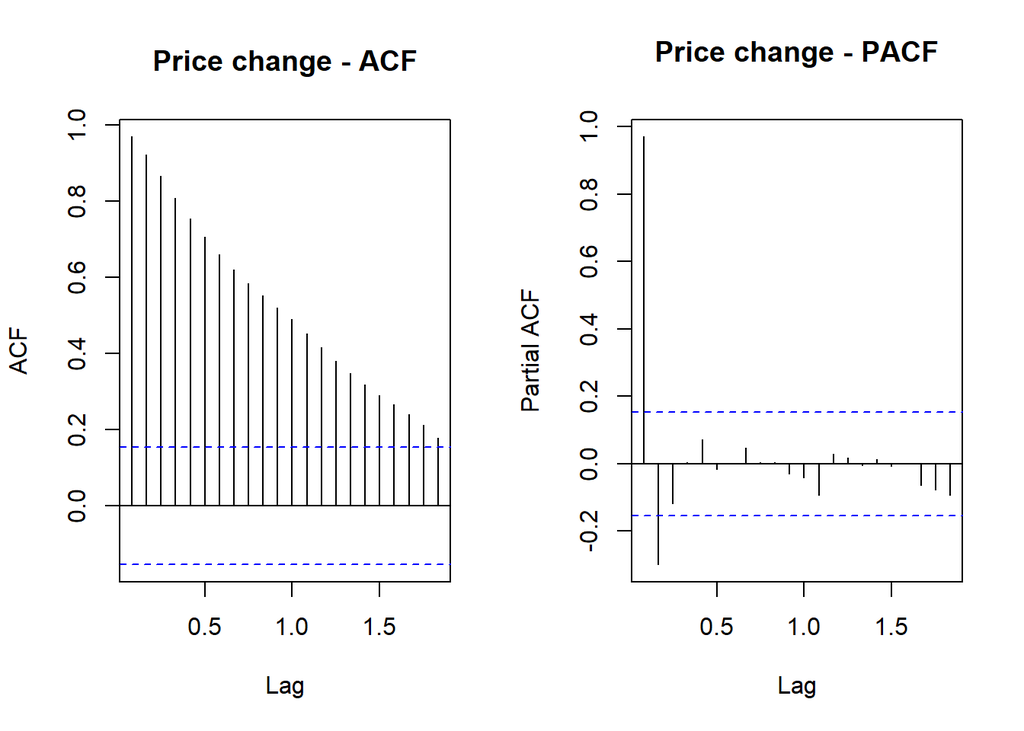

```
##
##  Augmented Dickey-Fuller Test
##
## data:  x
## Dickey-Fuller = -1.8523, Lag order = 5, p-value = 0.6379
## alternative hypothesis: stationary
```

```r
Stationary_Check(v_CRUDE_price_TS)
```

Fig 13: CRUDE price change - ACF Fig 14: CRUDE price change - PACF

The decrease in the ACF plot and a high peak in the PACF plot in the beginning, suggests that there is some pattern in the CRUDE price trend.

Hypotheses : H0 : The data is not stationary. HA : The data is stationary.

Interpretations: p - value : 0.6379 > 0.5

p - value is greater than 0.5 and hence the test is not statistically significant. Therefore, we fail to reject Null hypothesis i.e., The data is not stationary.

Also, as there is change in variance suggesting that the series is not stationary.

Therefore, the CRUDE price series is non - stationary.

Checking for Stationary on COPPER price

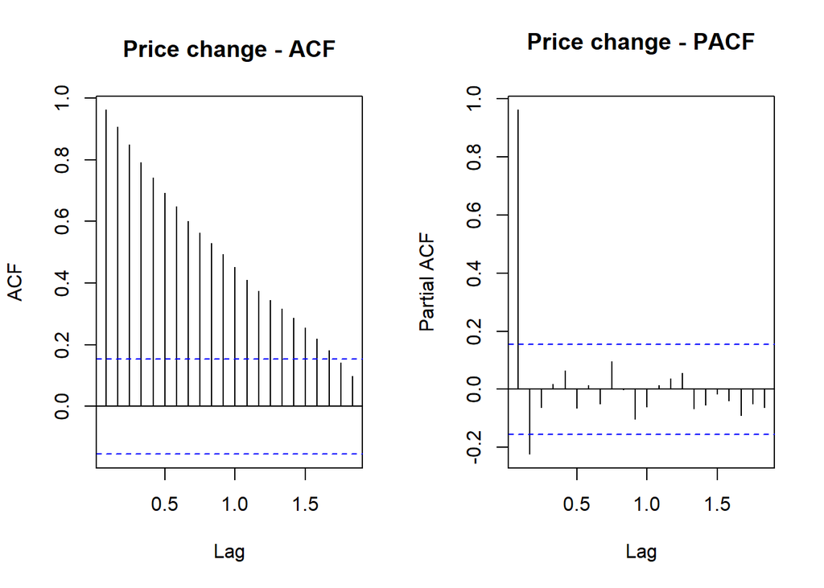

```
##
##  Augmented Dickey-Fuller Test
##
## data:  x
## Dickey-Fuller = -2.2502, Lag order = 5, p-value = 0.472
## alternative hypothesis: stationary
```

```r
Stationary_Check(v_COPPER_price_TS)
```

Fig 15: COPPER price change - ACF Fig 16: COPPER price change - PACF

The decrease in the ACF plot and a high peak in the PACF plot in the beginning, suggests that there is some pattern in the COPPER price trend.

Hypotheses : H0 : The data is not stationary. HA : The data is stationary.

Also, as there is change in variance suggesting that the series is not stationary.

Therefore, the COPPER price series is non - stationary.

## Impact of components on each time series.

The components of a series are usually,

1. Seasonality
2. Trend
3. Remainder

We should decompose the time series into the above components as we can see the impact of these components on the series data.

For this STL decomposition is used, as there is intervention in some of the series. This intervention is might be due to outliers and STL decomposition is robust in the case of outliers.

Decomposing ASX price series into components.

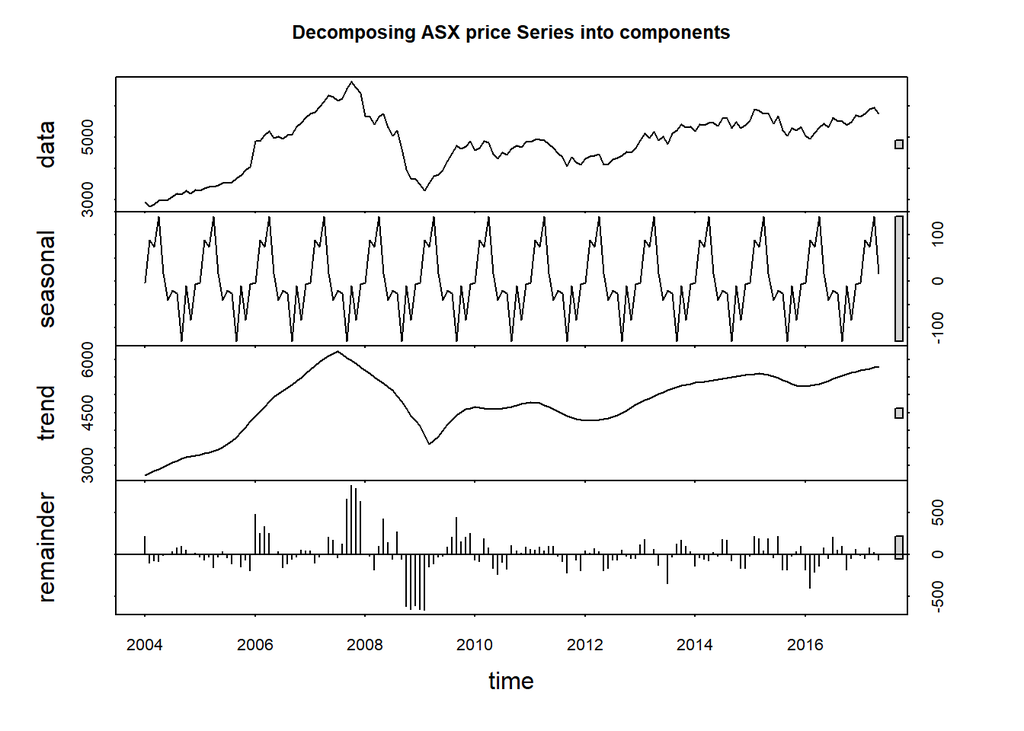

```r
v_ASX_stl_decomp <- stl(v_ASX_price_TS, t.window = 15, s.window = "periodic", robust = TRUE)
plot(v_ASX_stl_decomp, main = "Decomposing ASX price Series into components")
```

Fig 17: Decomposing ASX price series into components - stl decomposition.

1. The seasonal adjusted series is not meaningful in this case as it much deviated from the original series. Suggesting that there is no seasonality in the series as stated earlier.
2. The trend in the series data is shown exactly by the trend component.
3. Remainder component shows a high intervention point around 2008 depicting the real time global financial effect.

Decomposing GOLD price series into components.

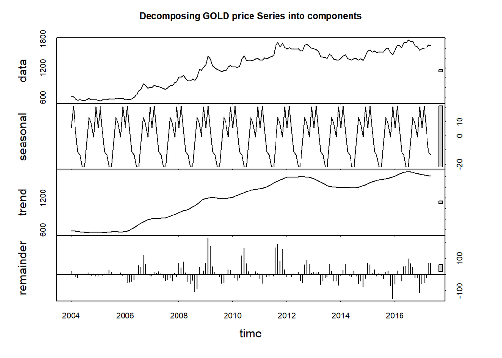

```r
v_GOLD_stl_decomp <- stl(v_GOLD_price_TS, t.window = 15, s.window = "periodic", robust = TRUE)
plot(v_GOLD_stl_decomp, main = "Decomposing GOLD price Series into components")
```

Fig 18: Decomposing GOLD price series into components - stl decomposition.

1. The seasonal adjusted series is not meaningful in this case as it much deviated from the original series. Suggesting that there is no seasonality in the series as stated earlier.
2. The trend in the series data is shown exactly by the trend component.
3. Remainder component shows a high intervention point at multiple points.

Decomposing CRUDE price series into components.

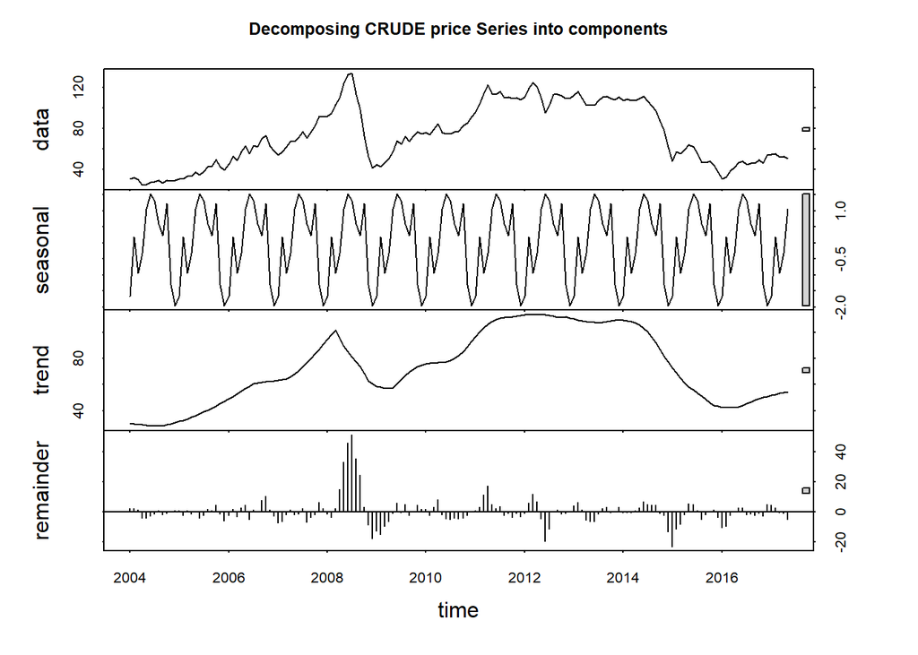

```r
v_CRUDE_stl_decomp <- stl(v_CRUDE_price_TS, t.window = 15, s.window = "periodic", robust = TRUE)
plot(v_CRUDE_stl_decomp, main = "Decomposing CRUDE price Series into components")
```

Fig 19: Decomposing CRUDE price series into components - stl decomposition.

1. The seasonal adjusted series is not meaningful in this case as it much deviated from the original series. Suggesting that there is no seasonality in the series as stated earlier.
2. The trend in the series data is shown exactly by the trend component.
3. Remainder component shows a high intervention point in 2008 depicting the real time global financial effect.

Decomposing COPPER price series into components.

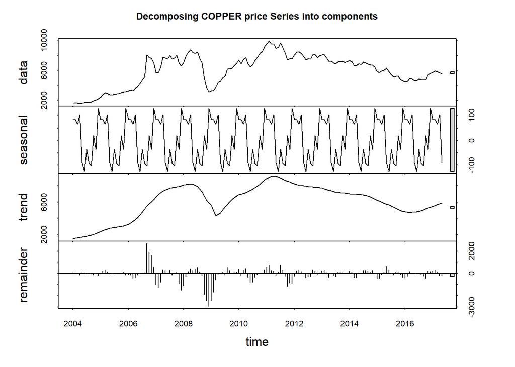

```r
v_COPPER_stl_decomp <- stl(v_COPPER_price_TS, t.window = 15, s.window = "periodic", robust = TRUE)
plot(v_COPPER_stl_decomp, main = "Decomposing COPPER price Series into components")
```

Fig 20: Decomposing COPPER price series into components - stl decomposition.

1. The seasonal adjusted series is not meaningful in this case as it much deviated from the original series. Suggesting that there is no seasonality in the series as stated earlier.
2. The trend in the series data is shown exactly by the trend component.
3. Remainder component shows a high intervention point around 2008 depicting the real time global financial effect.

## Suitable distributed lag model for ASX price index.

# Finite distributed lag model

```r
x = v_COPPER_price_TS # Independent variable1
z = v_GOLD_price_TS # Independent variable2
y = v_ASX_price_TS # Dependent variable


for ( i in 1:10){
  model_1 = dlm(x = as.vector(x) , y = as.vector(y), q = i )
  cat("q = ", i, "AIC = ", AIC(model_1$model), "BIC = ", BIC(model_1$model),"\n")
  }
```

```
## q =  1 AIC =  2574.488 BIC =  2586.789
## q =  2 AIC =  2559.356 BIC =  2574.7
## q =  3 AIC =  2544.155 BIC =  2562.531
## q =  4 AIC =  2528.895 BIC =  2550.289
## q =  5 AIC =  2513.265 BIC =  2537.664
## q =  6 AIC =  2497.775 BIC =  2525.166
## q =  7 AIC =  2481.988 BIC =  2512.357
## q =  8 AIC =  2466.511 BIC =  2499.846
## q =  9 AIC =  2451.016 BIC =  2487.302
## q =  10 AIC =  2436.164 BIC =  2475.389
```

As we have the least AIC and BIC values at q = 10. Let us fit the finite distributed lag model with q = 10.

```r
# Finite lag length based on AIC-BIC

finite_dlm = dlm( x = as.vector(x) , y = as.vector(y), q = 10)
summary(finite_dlm)
```

```
##
## Call:
## lm(formula = model.formula, data = design)
##
## Residuals:
##      Min       1Q   Median       3Q      Max
## -1154.09  -643.75   -11.55   596.33  1429.23
##
## Coefficients:
##               Estimate Std. Error t value Pr(>|t|)
## (Intercept)  3.981e+03  2.166e+02  18.382   <2e-16 ***
## x.t          1.536e-01  1.354e-01   1.134    0.259
## x.1          1.857e-02  2.205e-01   0.084    0.933
## x.2          4.480e-02  2.220e-01   0.202    0.840
## x.3          2.830e-02  2.180e-01   0.130    0.897
## x.4          1.889e-02  2.175e-01   0.087    0.931
## x.5         -4.846e-02  2.191e-01  -0.221    0.825
## x.6          3.046e-02  2.175e-01   0.140    0.889
## x.7         -3.494e-03  2.189e-01  -0.016    0.987
## x.8         -1.349e-03  2.239e-01  -0.006    0.995
## x.9         -8.232e-02  2.222e-01  -0.371    0.712
## x.10        -1.012e-02  1.340e-01  -0.076    0.940
## ---
## Signif. codes:  0 '***' 0.001 '**' 0.01 '*' 0.05 '.' 0.1 ' ' 1
##
## Residual standard error: 737.4 on 139 degrees of freedom
## Multiple R-squared:  0.1931, Adjusted R-squared:  0.1292
## F-statistic: 3.024 on 11 and 139 DF,  p-value: 0.001201
##
## AIC and BIC values for the model:
##        AIC      BIC
## 1 2436.164 2475.389
```

Hypotheses : H0 : The data doesn′t fit the Finite distributed lag model. HA : The data fits the Finite distributed lag model.

Interpretations: F - statistic is 3.024 R - squared is 0.1931 Adjusted R - squared is 0.1292 Degrees of freedom - DF are (11, 139) p - value (0.001201) is < 0.05 and therefore, it is statistically significant. Therefore, Null hypothesis is rejected. Hence, the model fits the Finite distributed lag model.

This model suggests that there is only 19.31% of data variance. Suggesting that the model explains only 19.31% of the trend. Which implies that the model shows some trend.

## Residual analysis

```r
# Function for residual analysis.

res_analysis <- function(res_m) {

    par(mfrow = c(2, 2))
    # Scatter plot for model residuals
    plot(res_m, type = "b", pch = 19, col = "blue", xlab = "years", ylab = "Standardized Residuals", main = "Plot of Residuals over Time")

    abline(h = 0)

    # Standard distribution
    hist(res_m, xlab = 'Standardized Residuals', freq = FALSE)
    curve(dnorm(x, mean = mean(res_m), sd = sd(res_m)), col = "red", lwd = 2, add = TRUE, yaxt = "n")

    # QQplot for model residuals
    qqnorm(res_m, col = c("blue"))
    qqline(res_m)

    # Auto-Correlation Plot
    acf(res_m, main = "ACF of Standardized Residuals",col=c("blue"))
}
```

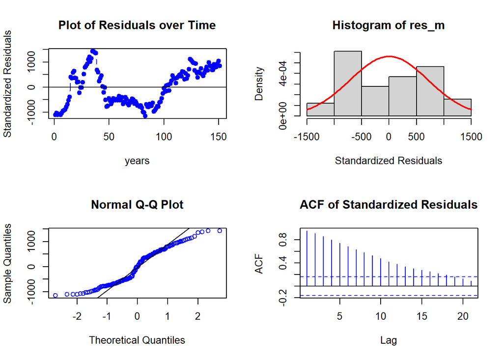

```r
res_analysis(residuals(finite_dlm$model))
```

Residual Analysis for Finite DLM:

Therefore, Further analysis is needed by adding polynomial to the lag model.

# Polynomial distributed lag model

```r
for (i in 1:3){
  model_2 <-  polyDlm(x = as.vector(x) , y = as.vector(y), q = i , k = i, show.beta = FALSE)
  cat("q = ", i, "k = ", i, "AIC = ", AIC(model_2$model), "BIC = ", BIC(model_2$model),"\n")
}
```

```
## q =  1 k =  1 AIC =  2574.488 BIC =  2586.789
## q =  2 k =  2 AIC =  2559.356 BIC =  2574.7
## q =  3 k =  3 AIC =  2544.155 BIC =  2562.531
```

Let us fit a polynomial model of order 3. Since least AIC and BIC scores.

```r
# Ploynomial DLM

PolyDLM_model = polyDlm(x = as.vector(x), y = as.vector(y), q = 3, k = 3, show.beta = TRUE)
```

```
## Estimates and t-tests for beta coefficients:
##        Estimate Std. Error t value P(>|t|)
## beta.0   0.1680      0.131   1.290   0.201
## beta.1   0.0419      0.210   0.199   0.842
## beta.2   0.0636      0.210   0.302   0.763
## beta.3  -0.0578      0.129  -0.448   0.655
```

```r
summary(PolyDLM_model)
```

```
##
## Call:
## "Y ~ (Intercept) + X.t"
##
## Residuals:
##      Min       1Q   Median       3Q      Max
## -1332.00  -699.29   -97.89   621.39  1553.44
##
## Coefficients:
##               Estimate Std. Error t value Pr(>|t|)
## (Intercept) 3539.99286  185.97839  19.034   <2e-16 ***
## z.t0           0.16811    0.13081   1.285    0.201
## z.t1          -0.29701    1.04763  -0.284    0.777
## z.t2           0.21928    0.96450   0.227    0.820
## z.t3          -0.04846    0.21330  -0.227    0.821
## ---
## Signif. codes:  0 '***' 0.001 '**' 0.01 '*' 0.05 '.' 0.1 ' ' 1
##
## Residual standard error: 742.7 on 153 degrees of freedom
## Multiple R-squared:  0.2733, Adjusted R-squared:  0.2543
## F-statistic: 14.39 on 4 and 153 DF,  p-value: 5.404e-10
```

Hypotheses : H0 : The data doesn′t fit the Polynomial distributed lag model. HA : The data fits the Polynomial distributed lag model.

This model suggests that there is only 27.33% of data variance. Suggesting that the model explains only 27.33% of the trend. Which implies that the model shows some trend.

## Residual analysis

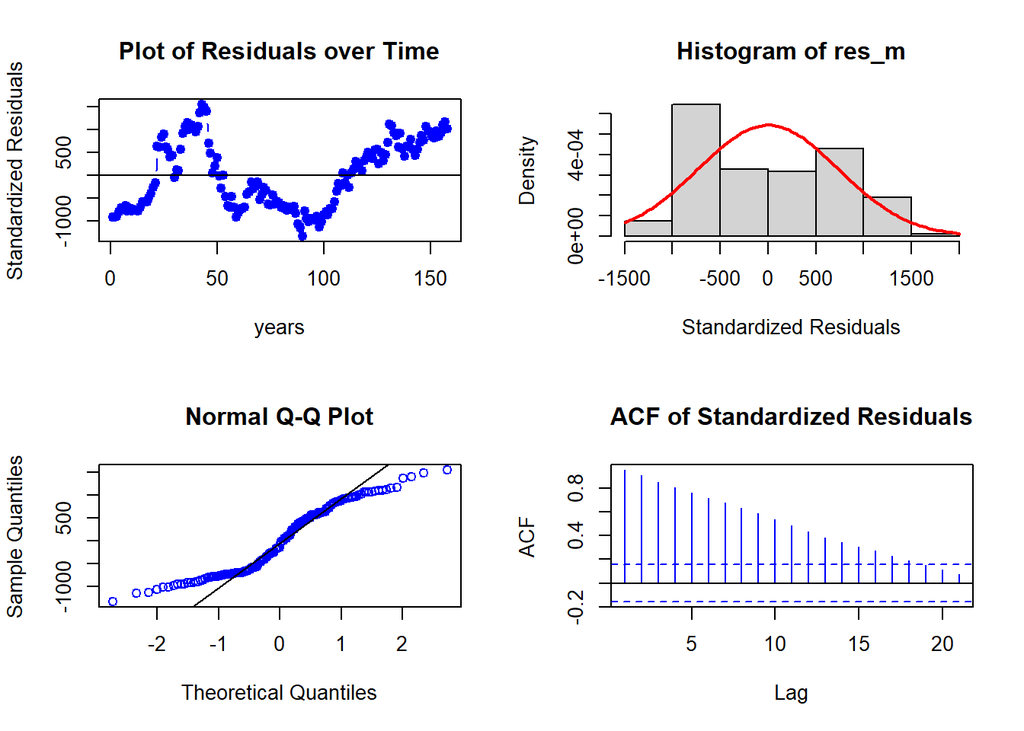

```r
res_analysis(residuals(PolyDLM_model$model))
```

Residual Analysis for Polynomial DLM:

This analysis is not enough and we still require a better model than this. Therefore, let us fit Koyck model.

# Koyck model

```r
# Koyk DLM

Koyck_DLM = koyckDlm(x = as.vector(x) , y = as.vector(y))
summary(Koyck_DLM)
```

```
##
## Call:
## "Y ~ (Intercept) + Y.1 + X.t"
##
## Residuals:
##     Min      1Q  Median      3Q     Max
## -689.64 -108.62   12.78  140.20  771.79
##
## Coefficients:
##               Estimate Std. Error t value Pr(>|t|)
## (Intercept) 189.368812  87.644648   2.161   0.0322 *
## Y.1           0.971621   0.021895  44.376   <2e-16 ***
## X.t          -0.005864   0.009517  -0.616   0.5387
## ---
## Signif. codes:  0 '***' 0.001 '**' 0.01 '*' 0.05 '.' 0.1 ' ' 1
##
## Residual standard error: 201.9 on 157 degrees of freedom
## Multiple R-Squared: 0.9485,  Adjusted R-squared: 0.9479
## Wald test:  1448 on 2 and 157 DF,  p-value: < 2.2e-16
##
## Diagnostic tests:
## NULL
##
##                             alpha         beta       phi
## Geometric coefficients:  6672.885 -0.005863623 0.9716211
```

Hypotheses : H0 : The data doesn′t fit the Koyck distributed lag model. HA : The data fits the Koyck distributed lag model.

This model suggests that there is only 94.85% of data variance. Suggesting that the model explains only 94.85% of the trend. Which implies that the model performs better on the series data.

Now let us perform residual analysis.

## Residual analysis

```r
res_analysis(residuals(Koyck_DLM))
```

[output not shown]

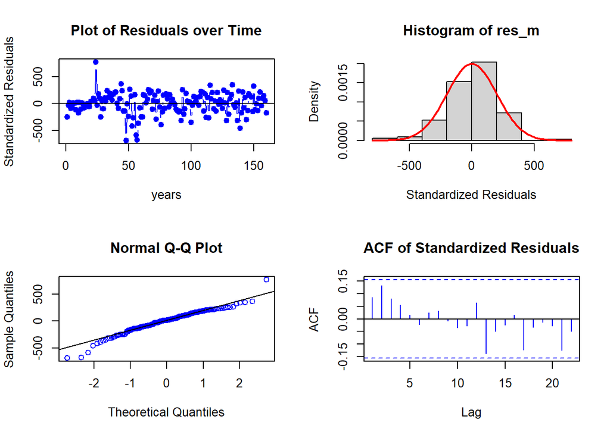

Residual Analysis for Koyck DLM:

So far this is the best model but let us fit ardlDlm model to check whether it fits better than Koyck model or not.

# Autoregressive distributed lag model

```r
for (i in 1:10){
  for(j in 1:5){
    model_4 = ardlDlm(x = as.vector(x) , y = as.vector(y), p = i , q = j )
    cat("p = ", i, "q = ", j, "AIC = ", AIC(model_4$model), "BIC = ", BIC(model_4$model),"\n")
  }
}
```

```
## p =  1 q =  1 AIC =  2147.741 BIC =  2163.116
## p =  1 q =  2 AIC =  2135.4 BIC =  2153.813
## p =  1 q =  3 AIC =  2121.12 BIC =  2142.558
## p =  1 q =  4 AIC =  2109.759 BIC =  2134.209
## p =  1 q =  5 AIC =  2099.056 BIC =  2126.505
## p =  2 q =  1 AIC =  2130.043 BIC =  2148.456
## p =  2 q =  2 AIC =  2132.038 BIC =  2153.52
## p =  2 q =  3 AIC =  2119.241 BIC =  2143.741
## p =  2 q =  4 AIC =  2107.649 BIC =  2135.155
## p =  2 q =  5 AIC =  2097.021 BIC =  2127.52
## p =  3 q =  1 AIC =  2117.307 BIC =  2138.745
## p =  3 q =  2 AIC =  2119.247 BIC =  2143.748
## p =  3 q =  3 AIC =  2119.696 BIC =  2147.259
## p =  3 q =  4 AIC =  2108.537 BIC =  2139.1
## p =  3 q =  5 AIC =  2097.832 BIC =  2131.38
## p =  4 q =  1 AIC =  2105.916 BIC =  2130.366
## p =  4 q =  2 AIC =  2107.774 BIC =  2135.28
## p =  4 q =  3 AIC =  2108.608 BIC =  2139.17
## p =  4 q =  4 AIC =  2110.085 BIC =  2143.704
## p =  4 q =  5 AIC =  2099.454 BIC =  2136.052
## p =  5 q =  1 AIC =  2095.118 BIC =  2122.566
## p =  5 q =  2 AIC =  2096.96 BIC =  2127.459
## p =  5 q =  3 AIC =  2097.887 BIC =  2131.436
## p =  5 q =  4 AIC =  2099.497 BIC =  2136.095
## p =  5 q =  5 AIC =  2101.419 BIC =  2141.067
## p =  6 q =  1 AIC =  2084.49 BIC =  2114.924
## p =  6 q =  2 AIC =  2086.331 BIC =  2119.809
## p =  6 q =  3 AIC =  2087.163 BIC =  2123.684
## p =  6 q =  4 AIC =  2088.704 BIC =  2128.268
## p =  6 q =  5 AIC =  2090.603 BIC =  2133.211
## p =  7 q =  1 AIC =  2072.833 BIC =  2106.239
## p =  7 q =  2 AIC =  2074.698 BIC =  2111.141
## p =  7 q =  3 AIC =  2075.535 BIC =  2115.016
## p =  7 q =  4 AIC =  2077.211 BIC =  2119.729
## p =  7 q =  5 AIC =  2079.174 BIC =  2124.729
## p =  8 q =  1 AIC =  2062.338 BIC =  2098.703
## p =  8 q =  2 AIC =  2064.181 BIC =  2103.577
## p =  8 q =  3 AIC =  2065.007 BIC =  2107.433
## p =  8 q =  4 AIC =  2066.679 BIC =  2112.135
## p =  8 q =  5 AIC =  2068.654 BIC =  2117.141
## p =  9 q =  1 AIC =  2049.983 BIC =  2089.293
## p =  9 q =  2 AIC =  2051.863 BIC =  2094.197
## p =  9 q =  3 AIC =  2052.445 BIC =  2097.803
## p =  9 q =  4 AIC =  2054.13 BIC =  2102.512
## p =  9 q =  5 AIC =  2056.102 BIC =  2107.508
## p =  10 q =  1 AIC =  2034.551 BIC =  2076.793
## p =  10 q =  2 AIC =  2036.144 BIC =  2081.403
## p =  10 q =  3 AIC =  2036.502 BIC =  2084.779
## p =  10 q =  4 AIC =  2037.935 BIC =  2089.229
## p =  10 q =  5 AIC =  2039.913 BIC =  2094.224
```

p = 10 and q = 1 has the least AIC and BIC scores.

```r
# ARDLM model

AR_DLM = ardlDlm(x = as.vector(x) , y = as.vector(y), p = 10 , q = 1 )
summary(AR_DLM)
```

```
##
## Time series regression with "ts" data:
## Start = 11, End = 161
##
## Call:
## dynlm(formula = as.formula(model.text), data = data, start = 1)
##
## Residuals:
##     Min      1Q  Median      3Q     Max
## -591.71 -104.56   -9.24  126.64  729.10
##
## Coefficients:
##               Estimate Std. Error t value Pr(>|t|)
## (Intercept)  2.362e+02  1.039e+02   2.273   0.0246 *
## X.t          7.806e-02  3.575e-02   2.183   0.0307 *
## X.1         -3.751e-02  5.815e-02  -0.645   0.5200
## X.2         -4.639e-04  5.855e-02  -0.008   0.9937
## X.3         -1.595e-02  5.751e-02  -0.277   0.7820
## X.4         -1.247e-02  5.736e-02  -0.217   0.8283
## X.5         -5.529e-02  5.779e-02  -0.957   0.3404
## X.6          6.729e-02  5.736e-02   1.173   0.2427
## X.7         -4.951e-03  5.772e-02  -0.086   0.9318
## X.8         -4.301e-02  5.904e-02  -0.728   0.4676
## X.9         -6.099e-02  5.859e-02  -1.041   0.2997
## X.10         7.708e-02  3.540e-02   2.178   0.0311 *
## Y.1          9.648e-01  2.237e-02  43.134   <2e-16 ***
## ---
## Signif. codes:  0 '***' 0.001 '**' 0.01 '*' 0.05 '.' 0.1 ' ' 1
##
## Residual standard error: 194.5 on 138 degrees of freedom
## Multiple R-squared:  0.9443, Adjusted R-squared:  0.9394
## F-statistic: 194.9 on 12 and 138 DF,  p-value: < 2.2e-16
```

Hypotheses : H0 : The data doesn′t fit the Autoregressive distributed lag model. HA : The data fits the Autoregressive distributed lag model.

This model suggests that there is only 94.43% of data variance. Suggesting that the model explains only 94.43% of the trend. Which implies that the model shows some trend.

Let us perform residual analysis on this model.

## Residual analysis

```r
res_analysis(residuals(AR_DLM))
```

[output not shown]

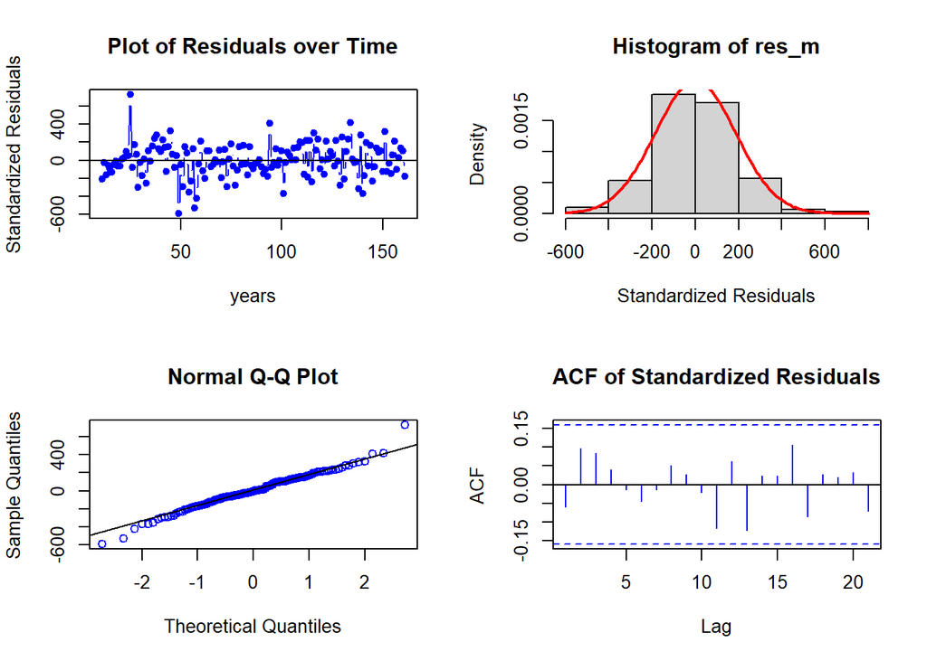

Residual Analysis for Auto Regressive DLM:

Even though Auto Regressive DLM shown better performance, Koyck model fits better with 94.85% variance.

# Conclusion